# Question

Las tablas 1 y 2 muestran algunos valores de las funciones f(x) y g(x) respectivamente.

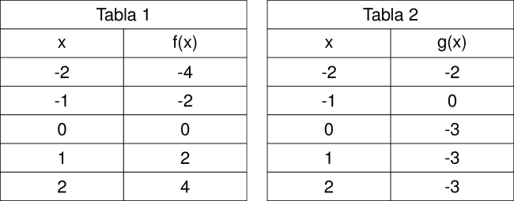

Con estas funciones se puede crear una nueva función: h(x)=g(f(x)).

Para calcular los valores de esta función, a partir de la información de las tablas 1 y 2, se debe efectuar este procedimiento:

- **Paso 1**. Escoger el valor de x con el que se va a calcular h(x).
- **Paso 2**. Ubicar el valor escogido en el paso 1, en la columna de x de la tabla 1 y tomar el valor de f(x) que se encuentra frente a este.
- **Paso 3**. Ubicar el valor hallado en el paso 2, en la columna de x de la tabla 2, y tomar el valor de g(x) que se encuentra frente a este.
- **Paso 4**. El valor encontrado en el paso 3 corresponde a h(x).

Con base en lo anterior, ¿es posible hallar el valor de h(-2)?

## Answerlist

- Sí, porque se conocen los valores de f(x) y g(x) para los mismos valores de x
- No, porque falta información sobre la función g(x) para completar el procedimiento
- Sí, porque ese valor de x aparece en ambas columnas de las tablas de f(x) y g(x)
- No, porque se desconoce la fórmula utilizada para calcular los valores de f(x)

# Solution

La respuesta correcta es: No, porque falta información sobre la función g(x) para completar el procedimiento

Explicación:

Para calcular h(-2), seguimos los pasos del procedimiento:

1. Escogemos x = -2
2. En la tabla 1, para x = -2, f(-2) = -4
3. Ahora debemos buscar x = -4 en la tabla 2, pero este valor no está presente en la columna x de la tabla 2.

Por lo tanto, no podemos completar el paso 3 y, en consecuencia, no podemos hallar h(-2).

El problema radica en que la función g(x) no está definida para todos los valores que produce f(x). En este caso específico, no tenemos información sobre g(-4), que es necesaria para calcular h(-2) = g(f(-2)) = g(-4).

Esta situación ilustra una limitación importante cuando trabajamos con funciones compuestas definidas por tablas de valores: necesitamos que el rango de la primera función (f) esté contenido en el dominio de la segunda función (g) para poder calcular todos los valores de la función compuesta (h).

# Meta-information

exname: Función Compuesta extype: schoice exsolution: 0100 exshuffle: TRUE